# Leopard Lives Matter

### or Hunting the Hunter

Just like in real life, leopards are threatened species in EVE Online. Especially those in Jita:

[figure not shown]

There is a poacher who specialises in smartbombing to death Leopards in warp. We the people of New Eden's Institute for Wildlife Preservation, Useless Science, and Engingeering (NEIWPUSE) cannot accept such an atrocious and unlawful behaviour and need to do something. Protest, maybe? Or bump the hell out of the poacher (a CODE. agent, no less)... But first, we need to find her.

We'll do that using some Python 3 with Pandas, scikit-learn, Matplotlib, and Requests. If you are running this notebook, chances are you already have all those installed.

#### Version History

2021-09-27: Initial version

2021-10-15: Work around abuse protections on zkillboard (wasn't me, really)

2021-10-17: Solved the origin of the puzzling cluster of killmails

## Preamble

We start by defining some constants with CCP IDs of stuff we will need later. By adjusting the values below, the notebook can be reused for other similar cases.

```python
# Hunter character ID (from the zKillboard profile URL)
CID_HUNTER = 95318765

# Location ID - Jita system
LID_JITA = 30000142

# Type ID - Leopard
TID_LEOPARD = 33513

# Type ID - Large YF-12a Smartbomb
TID_YFLARGE = 9808
```

## Obtaining the Data

First order of business is to obtain the killmails seen in the screenshot above. We cannot use ESI to query for killmails of other users but we can use the zKillboard API to scrape whatever killmals are available. The `/kills/characterID/{character_id}/` endpoint returns a list of recent kills from character with CCP ID `{character_id}`. The list consists of entries in the following format:

```
{
    "killmail_id": 1234,
    "zkb": {
        "locationID": 1234,
        "hash": "foobarbaz",
        // other irrelevant fields
    }
}
```

`locationID` is the ID of the celestial closest to the spot where the kill ocurred. We need the combination of `killmail_id` and `hash` to fetch the actual killmails from ESI. Since we are only interested in kills that happen in Jita, we will obtain the list of location IDs in Jita and use it to filter the list from zKillboard before we turn to ESI to download the actual killmails. ESI provides the `/universe/systems/{system_id}/` endpoint for querying system information. Let's see what's in Jita:

```python
from pprint import pprint
import requests as req

jita = req.get(f'https://esi.evetech.net/latest/universe/systems/{LID_JITA}/').json()
pprint(jita)
```

```
{'constellation_id': 20000020,
 'name': 'Jita',
 'planets': [{'planet_id': 40009077},
             {'planet_id': 40009078},
             {'moons': [40009081], 'planet_id': 40009080},
             {'moons': [40009083,
                        40009084,
                        40009085,
                        40009087,
                        40009088,
                        40009089,
                        40009090,
                        40009091,
                        40009092,
                        40009093,
                        40009094,
                        40009097],
              'planet_id': 40009082},
             {'moons': [40009099,
                        40009100,
                        40009101,
                        40009102,
                        40009103,
                        40009104,
                        40009105,
                        40009106,
                        40009107,
                        40009108,
                        40009109,
                        40009110,
                        40009111,
                        40009112,
                        40009113,
                        40009114,
                        40009115],
              'planet_id': 40009098},
             {'moons': [40009118], 'planet_id': 40009116},
             {'moons': [40009121, 40009122], 'planet_id': 40009119},
             {'planet_id': 40009123}],
 'position': {'x': -1.2906486173487826e+17,
```

[output cut: 12 more lines]

```
 'stations': [60000361,
              60000364,
              60000451,
              60000463,
              60002953,
              60002959,
              60003055,
              60003460,
              60003463,
              60003466,
              60003469,
              60003757,
              60003760,
              60004423],
 'system_id': 30000142}
```

There are planets with moons, stations, stargates, and the star itself. Let's collect all the IDs in a set:

```python
jita_locs = {jita['system_id'], jita['star_id']}
for obj_type in ['stations', 'stargates']:
    jita_locs.update(jita[obj_type])
for planet in jita['planets']:
    jita_locs.add(planet['planet_id'])
    jita_locs.update(planet.get('moons', []))

print(len(jita_locs), "locations in Jita")
```

```
64 locations in Jita
```

We can now filter the killmails to only those in Jita. Packing it in a function will make our life easier:

```python
# This used to be much simpler, but zKillboard made their API unavailable due to
# abuses. To access it, one needs a browser capable of running JavaScript. We
# can still go the good old way and parse the HTML pages.
# This takes waaaay longer though - be patient (or enable printing in parse_kill_page)

from bs4 import BeautifulSoup
import re
import time

RE_KILL = re.compile(r'^/kill/\d+/')
RE_SYSTEM = re.compile(r'^/system/\d+/')
RE_ESI = re.compile(r'/latest/killmails/\d+/[0-9a-f]+/')

ZKILL_CACHE = {}

try:
    import pickle
    with open('zkill.cache', 'rb') as f:
        ZKILL_CACHE = pickle.load(f)
except FileNotFoundError:
    pass

def cached_zkill_get(s, url):
    global ZKILL_CACHE
    if url not in ZKILL_CACHE:
        r = s.get(url)
        time.sleep(0.33)
        if r.status_code != 200:
            print("While fetching", url)
            print("got bad HTTP response from ESI:", r.status_code)
            raise ConnectionError()
        ZKILL_CACHE[url] = r.text
    return ZKILL_CACHE[url]

def parse_kill_page(s, url):
    # print("Parsing", url)
    r = cached_zkill_get(s, url)
    soup = BeautifulSoup(r, 'html.parser')
    loc = soup.find('a', href=RE_SYSTEM).get('href').split('/')[2]
    km_parts = soup.find('a', href=RE_ESI).get('href').split('/')[5:7]
    return dict(id=int(km_parts[0]), hash=km_parts[1], locationID=int(loc))

def parse_index_page(s, content):
    soup = BeautifulSoup(content, 'html.parser')
    links = set([link.get('href') for link in soup.find_all('a', href=RE_KILL)])
    return [parse_kill_page(s, 'https://zkillboard.com' + link) for link in links]

def get_jita_killmail_ids(char_id, page=1):
    s = req.Session()
    s.headers['User-Agent'] = 'Mozilla/5.0 (Macintosh; Intel Mac OS X 10.15; rv:93.0) Gecko/20100101 Firefox/93.0'
    r = s.get(f'https://zkillboard.com/character/{char_id}/kills/page/{page}/')
    return [km for km in parse_index_page(s, r.text) if km['locationID'] == LID_JITA]

# This is the entire code when using the API
#
# def get_jita_killmail_ids(char_id, page=1):
#     r = s.get(f'https://zkillboard.com/api/kills/characterID/{char_id}/page/{page}/')
#     content = r.json()
#     return [{'id': km['killmail_id'],
#              'hash': km['zkb']['hash'],
#              'locationID': km['zkb']['locationID']}
#             for km in content if km['zkb']['locationID'] in jita_locs]
```

```python
# This list is four times as short when the zKillboard API can be used
zkillmails = []
for page in range(1, 9):
    zkillmails.extend(get_jita_killmail_ids(CID_HUNTER, page=page))
    print(len(zkillmails), "killmails in total")
zkillmails.sort(key=lambda x: x['id'], reverse=True)
```

```
50 killmails in total
100 killmails in total
150 killmails in total
200 killmails in total
250 killmails in total
300 killmails in total
342 killmails in total
392 killmails in total
```

Let's see what ESI gives us in a killmail. The relevant endpoint is `/killmails/{killmail_id}/{killmail_hash}/`.

```python
pprint(req.get(f"https://esi.evetech.net/latest/killmails/{zkillmails[0]['id']}/{zkillmails[0]['hash']}/").json())
```

```
{'attackers': [{'character_id': 95318765,
                'corporation_id': 98539581,
                'damage_done': 557,
                'final_blow': True,
                'security_status': -0.8,
                'ship_type_id': 624,
                'weapon_type_id': 9808}],
 'killmail_id': 95901530,
 'killmail_time': '2021-10-14T16:19:13Z',
 'solar_system_id': 30000142,
 'victim': {'character_id': 649081869,
            'corporation_id': 98370339,
            'damage_taken': 557,
            'items': [],
            'position': {'x': -4067483557936.244,
                         'y': -710543304306.2552,
                         'z': -3956408162806.7026},
            'ship_type_id': 33513}}
```

A lot of interesting information here. `attackers` is the list of attackers, including the type of ship they flew. The most interesting information though is contained in the `victim` field and that is the `position` field holding the 3d space coordinates of the location where the kill ocurred. We also have the ship type of the victim, something that the zKillboard data did not provide.

Let's write a function that downloads a killmail, checks if the victim was a Leopard in Jita and if so, returns the time and location of the kill. Also, we are only interested in solo kills with specific kind of thermal smartbomb as the poor Leopard has a thermal resistance hole.

Since we are going to be playing with a lot of ESI calls, it is a good idea to cache them locally so that we do not unnecessary hit the API server. The information we are interested in is static, so we also save and load the ESI cache by pickling it in order to reuse it in different sessions.

```python
import time

ESI_CACHE = {}

try:
    import pickle
    with open('esi.cache', 'rb') as f:
        ESI_CACHE = pickle.load(f)
except FileNotFoundError:
    pass

def cached_esi_call(url):
    global ESI_CACHE
    if url not in ESI_CACHE:
        r = req.get(url)
        time.sleep(1.0)
        if r.status_code != 200:
            print("While fetching", url)
            print("got bad HTTP response from ESI:", r.status_code)
            raise ConnectionError()
        ESI_CACHE[url] = r.json()
    return ESI_CACHE[url]

def get_killmail_if_interesting(km_id, km_hash):
    km = cached_esi_call(f"https://esi.evetech.net/latest/killmails/{km_id}/{km_hash}/")
    attackers = km['attackers']
    # Should not happen but let's safeguard anyway
    if km['solar_system_id'] != LID_JITA:
        print("Location is not Jita - check filter list")
        return None
    # Only solo kills
    if len(attackers) > 1:
        print("Not a solo killmail")
        return None
    # Only large thermal smartbombs
    if attackers[0]['weapon_type_id'] != TID_YFLARGE:
        print("Didn't die to a large YF-12a smartbomb")
        return None
    # Only Leopards
    victim = km['victim']
    if victim['ship_type_id'] != TID_LEOPARD:
        print("Not a Leopard")
        return None
    # Extract useful information
    victim_pos = km['victim']['position']
    return {
        'id': km_id,
        'time': km['killmail_time'],
        'x': victim_pos['x'],
        'y': victim_pos['y'],
        'z': victim_pos['z']
    }
```

ESI may rate-limit us if we hit it too hard, which is why we insert a small 1 second delay after each request. We do not want to deal with rate limit errors, or with any other kind of errors, so we simply raise an exception when that happens. Let's test the function with two killmails: an interesting and a not so interesting one:

```python
get_killmail_if_interesting(95106619, '4063f34c3f0ee234a8a6af4fa71cc971295db41c')
```

```
{'id': 95106619,
 'time': '2021-09-13T18:19:22Z',
 'x': -4067483559253.9316,
 'y': -710543302303.4763,
 'z': -3956408162591.11}
```

```python
get_killmail_if_interesting(94352163, '666e7d633455f51e143755f3a8fd1a5953ed9a08')
```

```
Not a Leopard
```

Works as expected. Now let's download all the killmails. The whole thing runs for several minutes due to the delay in the function that calls ESI (or instantly, if all requests are cached already). Because we cache the requests, if an error occurs, we can simply reevaluate the entire cell. Smart, right?

```python
km_data = []

for n, zkm in enumerate(zkillmails[:375]):
    # print(f"Fetching killmail {n+1:3d}/{len(zkillmails)}: {zkm['id']}")
    killmail = get_killmail_if_interesting(zkm['id'], zkm['hash'])
    if killmail is not None:
        km_data.append(killmail)
```

```
Not a Leopard
Not a Leopard
Didn't die to a large YF-12a smartbomb
Not a Leopard
Not a Leopard
Didn't die to a large YF-12a smartbomb
Didn't die to a large YF-12a smartbomb
Didn't die to a large YF-12a smartbomb
Didn't die to a large YF-12a smartbomb
Didn't die to a large YF-12a smartbomb
Didn't die to a large YF-12a smartbomb
Didn't die to a large YF-12a smartbomb
Didn't die to a large YF-12a smartbomb
Didn't die to a large YF-12a smartbomb
```

## Analysing the Data

Time to run some data analysis. Pandas makes it easy to work with tabular data like the killmails we obtained in the previous step. Let's create a dataset:

```python
import pandas as pd
import numpy as np

df = pd.DataFrame(km_data).set_index('id')
df.head()
```

| id | time | x | y | z |
| --- | --- | --- | --- | --- |
| 95901530 | 2021-10-14T16:19:13Z | -4.067484e+12 | -7.105433e+11 | -3.956408e+12 |
| 95899237 | 2021-10-14T14:23:22Z | -4.067484e+12 | -7.105433e+11 | -3.956408e+12 |
| 95882308 | 2021-10-13T16:46:54Z | -4.067484e+12 | -7.105433e+11 | -3.956408e+12 |
| 95881602 | 2021-10-13T16:06:12Z | -4.067484e+12 | -7.105433e+11 | -3.956408e+12 |
| 95580550 | 2021-10-01T15:35:46Z | -4.067484e+12 | -7.105433e+11 | -3.956408e+12 |

Before venturing forth, we need to talk about how to locate things in EVE.

## The Geometry of EVE

In their desire to create as realistic a simulation as possible, CCP went as far as representing the position of each star in EVE in metres on a shared galactic Cartesian coordinate system. to keep the position of each object in the EVE universe with very high accuracy down to a single metre. The objects within the solar systems (planets, moon, stations, etc.) use the same coordinate system but have their positions relative to their star. This allows for really precise computations using the game location data.

Because of the huge distances involved, working with the standard floating-point type of Python will not yield good results in some cases due to errors introduced by rounding. There, when that makes sense, we will use the `decimal` package that provides more textbook style, arbitrary precision decimal arithmetic.

Let's start with some plots that will help us better understand the data. We will produce X-Y, X-Z and Y-Z plots instead of the more fitting 3d plot since the latter is not easy and/or portable to do in Jupyter notebooks. But first we will fetch information about all space objects in Jita.

```python
def get_type_radius(type_id):
    type_info = cached_esi_call(f"https://esi.evetech.net/latest/universe/types/{type_id}/")
    return type_info['radius']

def get_space_object(obj_class, obj_id):
    data = cached_esi_call(f"https://esi.evetech.net/latest/universe/{obj_class}/{obj_id}/")
    radius = get_type_radius(data['type_id']) if 'type_id' in data else 0
    return {
        'id': obj_id,
        'name': data['name'],
        'pos': data['position'],
        'radius': radius,
        'class': obj_class[:-1]
    }

jita_space = {}
for station_id in jita['stations']:
    jita_space[station_id] = get_space_object('stations', station_id)

for gate_id in jita['stargates']:
    jita_space[gate_id] = get_space_object('stargates', gate_id)

for planet in jita['planets']:
    planet_id = planet['planet_id']
    jita_space[planet_id] = get_space_object('planets', planet_id)
    for moon_id in planet.get('moons', []):
        jita_space[moon_id] = get_space_object('moons', moon_id)
```

For each object, we get its name and its position, but also its radius. The radius of a space object is that of a simple sphere that fully envelops it. The game client shows the distance to the surface of that sphere as the distance to the object itself in the overview or next to a space bracket. The surface of the sphere is also where warp tunnels end. The radius is a property of the object type and all gates or stations of the same type have the same radius.

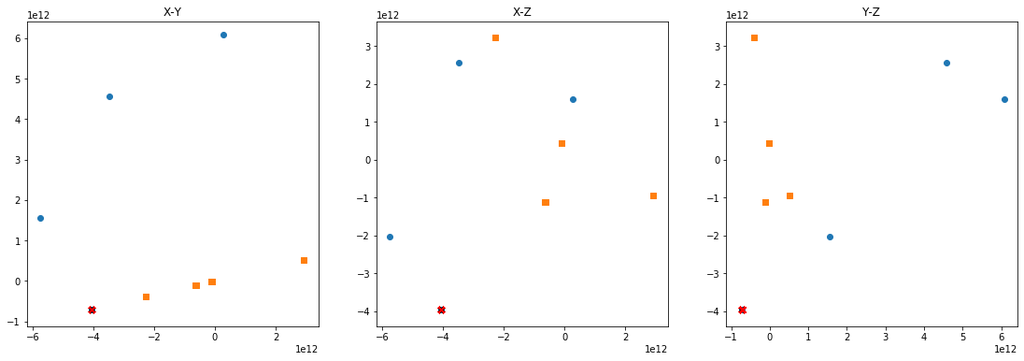

```python
%matplotlib inline

import matplotlib.pyplot as plt

plt.rcParams['figure.figsize'] = (19.0, 6.0)

def make_xyz_scatter_plots(axes, x, y, z, marker, c=None):
    ax1, ax2, ax3 = axes
    ax1.scatter(x=x, y=y, marker=marker, c=c)
    ax2.scatter(x=x, y=z, marker=marker, c=c)
    ax3.scatter(x=y, y=z, marker=marker, c=c)

def plot_cluster(data, ax_limit=None, outliers=None, space_objects=False):
    plt.figure(clear=True)
    fig, axes = plt.subplots(1, 3)

    if outliers is None:
        outliers = np.repeat(False, data.shape[0])

    if space_objects:
        gates_x = np.array([jita_space[g]['pos']['x'] for g in jita['stargates']])
        gates_y = np.array([jita_space[g]['pos']['y'] for g in jita['stargates']])
        gates_z = np.array([jita_space[g]['pos']['z'] for g in jita['stargates']])
        make_xyz_scatter_plots(axes, gates_x, gates_y, gates_z, 'o')

        stations_x = np.array([jita_space[s]['pos']['x'] for s in jita['stations']])
        stations_y = np.array([jita_space[s]['pos']['y'] for s in jita['stations']])
        stations_z = np.array([jita_space[s]['pos']['z'] for s in jita['stations']])
        make_xyz_scatter_plots(axes, stations_x, stations_y, stations_z, 's')

    make_xyz_scatter_plots(axes, data[~outliers,0], data[~outliers,1], data[~outliers,2], 'x', c='r')
    make_xyz_scatter_plots(axes, data[outliers,0], data[outliers,1], data[outliers,2], '+', c='y')

    axes[0].set_title("X-Y")
    axes[1].set_title("X-Z")
    axes[2].set_title("Y-Z")

    if ax_limit is not None:
        for ax in axes:
            ax.set_xlim((-ax_limit, ax_limit))
            ax.set_ylim((-ax_limit, ax_limit))

    plt.show()

plot_cluster(df[['x', 'y', 'z']].values, space_objects=True)
```

Looks like all killmails are near one of the gates. Let's take a closer look, this time without the space objects.

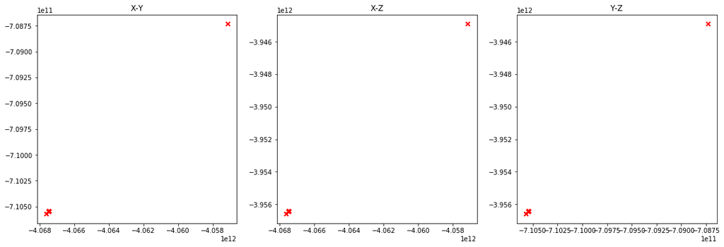

```python
plot_cluster(df[['x', 'y', 'z']].values, space_objects=False)
```

There are at least three groups of killmails and they kind of line up, but that could easily be an illusion. Let's cluster them using DBSCAN.

```python
from sklearn.cluster import DBSCAN
from sklearn.preprocessing import StandardScaler

X = StandardScaler().fit_transform(df[['x', 'y', 'z']].values)
db = DBSCAN(eps=0.001, min_samples=5).fit(X)
labels = set(db.labels_)
df['label'] = db.labels_

n_clusters = len(labels) - (1 if -1 in labels else 0)

print(f"DBSCAN produced {n_clusters} clusters")
for lbl in labels:
    count = (db.labels_ == lbl).sum()
    print(f"  Label {lbl}: {count} items")
```

```
DBSCAN produced 3 clusters
  Label 0: 327 items
  Label 1: 27 items
  Label 2: 7 items
```

We normalize the coordinates of the points using `StandardScaler` and run DBSCAN on them, which yields three clusters. One big with 327 killmails and two smaller ones with 27 and 7 killmails respectively. Let's focus on the big one.

Again, we use `StandardScaler` but this time set `with_std` to `False` which only shifts the cluster centroid to the origin of the coordinate system leaving the relative position of each killmail as is.

```
ΔX range [-1447, 1328] m
ΔY range [-1266, 1219] m
ΔZ range [-2462, 1795] m
R range [804, 2736] m
Outliers: 8
```

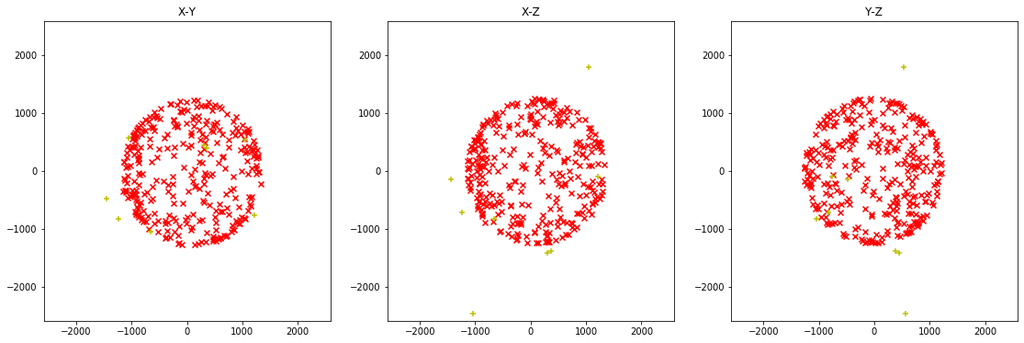

```python
def analyse_cluster(df_kills, label):
    data = df_kills[df_kills['label'] == label][['x', 'y', 'z']]
    scaler = StandardScaler(with_std=False).fit(data)

    X = scaler.transform(data)

    x_min, x_max = X[:,0].min(), X[:,0].max()
    y_min, y_max = X[:,1].min(), X[:,1].max()
    z_min, z_max = X[:,2].min(), X[:,2].max()

    lims = [x_min, x_max, y_min, y_max, z_min, z_max]
    max_abs_lim = 1.05 * max([np.abs(l) for l in lims])

    print(f"ΔX range [{x_min:.0f}, {x_max:.0f}] m")
    print(f"ΔY range [{y_min:.0f}, {y_max:.0f}] m")
    print(f"ΔZ range [{z_min:.0f}, {z_max:.0f}] m")

    r = np.linalg.norm(X, axis=1)

    print(f"R range [{np.min(r):.0f}, {np.max(r):.0f}] m")

    # Remove outliers
    r_mean = np.mean(r)
    is_outlier = (r - r_mean) / np.std(r) > 1.3
    print("Outliers:", is_outlier.sum())

    plot_cluster(X, ax_limit=max_abs_lim, outliers=is_outlier)

    scaler = StandardScaler(with_std=False).fit(data[~is_outlier])
    return scaler.mean_

centroid = analyse_cluster(df, label=0)
```

Although we know the exact 3d coordinates of the spot, EVE does not allow us to randomly warp anywhere in space. Instead, we can only warp to some of a predefined set of warp targets such as celestials, stations, gates, beacons, wrecks or bookmarked locations more than 150 km away from our current location. It is possible to warp only halfway through to the warp target by first depleting the ship's capacitor until there isn't enough charge left for the full warp, but that is difficult to calculate in advance and capacitor levels are quantised. Another option is to create a bookmark in mid-warp and then warp back to it, which is how most safespots are created. As we will see later on, bookmarks are also quantised, which complicates things.

Because of that peculiarity of the warp mechanic, there is a limited number of "official" warp trajectories that pass through $P_0$. Given the sheer number of killmails, we can safely assume that we are dealing with one such official trajectory, most likely one connecting a gate to the Jita 4-4 market. But let's not get ahead of ourselves and examine the situation thoroughly.

We are going to brute force all pairs of space objects. For each pair, we will examine how close $P_0$ is to the line connecting the origin and the target. For that we are going to use some vector math. The basic idea is to first compute the unit warp vector $u_w$ from the origin location $O$ to the target location $T$, then project the vector from $O$ to $P_0$ onto it, and finally use the Pythagorean theorem to find the distance from $P_0$ to its projection.

The warp vector is

$$ u_w = \frac{OT}{\lVert OT \rVert} $$

The projection of $P_0$ onto $OT$ is the point $P$ for which

$$ \lVert OP \rVert = \lVert OP_0 \rVert \cos \phi = OP_0 \cdot u_w $$

where $\cos \phi$ is the cosine of the angle between $u_w$ and $OP_0$. The distance from $P_0$ to $P$ is then

$$ d_{P0} = \lVert PP_0 \rVert = \sqrt{\lVert OP_0 \rVert^2 - \lVert OP \rVert^2} = \lVert OP_0 \rVert \sqrt{1 - \cos^2 \phi} $$

Finding the warp route with the smallest $d_{P0}$ is equivalent to finding the route that maximises $\cos \phi$. We are therefore going to work with $\cos \phi$ which can be easily computed following the definition of dot product in Cartesian space:

$$ \cos \phi = \frac{OP_0 \cdot u_w}{\lVert OP_0 \rVert} $$

Once we find the route that maximises $\cos \phi$, we will compute the distance to $P_0$. If that distance is below the range of the smartbombs, we have a winner.

Lets write some helper vector functions. Here, we will be using `Decimal` in order to obtain the highest accuracy possible.

```python
from decimal import Decimal

def vec_len(v):
    return sum([c**2 for c in v]).sqrt()

def vec_norm(v):
    l = vec_len(v)
    return [c / l for c in v]

def vec_dir(p1, p2):
    return vec_norm(vector(p1, p2))

def vec_dot(v1, v2):
    return sum([c1 * c2 for (c1, c2) in zip(v1, v2)])

def vector(p1, p2):
    return [c2 - c1 for (c1, c2) in zip(p1, p2)]

def distance(p1, p2):
    return vec_len(vector(p1, p2))

def to_dvec(v):
    return [Decimal(c) for c in (v['x'], v['y'], v['z'])]
```

Now for all combinations of space objects.

```python
# 1 A.U. in metres - let's hope CCP uses the same value :)
AU = Decimal('149597870700.0')

# 1 km in metres
KM = Decimal('1000.0')

def format_dist(d):
    if d >= Decimal('0.1') * AU:
        AUs = (d / AU).quantize(Decimal('.1'))
        return f"{AUs} AU"
    elif d >= Decimal('10') * KM:
        kms = (d / KM).quantize(Decimal('1.'))
        return f"{kms} km"
    return str(d.quantize(Decimal('1.'))) + " m"

def format_time(t):
    one = Decimal(1)
    in_ms = Decimal(1000)
    in_us = Decimal(1e+6)

    if t >= one:
        t_conv = t
        unit = " s"
        prec = Decimal('.001')
    elif t * in_ms >= one:
        t_conv = t * in_ms
        unit = " ms"
        prec = Decimal('.1')
    else:
        t_conv = t * in_us
        unit = " µs"
        prec = Decimal('.1')
    return str(t_conv.quantize(prec)) + unit

def find_best_route(point, verbose=False):
    best_route = None
    cosphi_max = Decimal()

    for origin_id in jita_space:
        origin = to_dvec(jita_space[origin_id]['pos'])
        d_point = distance(origin, point)
        u_op = vec_dir(origin, point)
        for target_id in jita_space:
            if target_id == origin_id:
                continue
            target = to_dvec(jita_space[target_id]['pos'])
            d_warp = distance(origin, target)
            d_tp = distance(target, point)
            # The second term below deserves some explanation:
            # Each route is represented twice with interchanged origin and target objects
            # We drop the case when the point is closer to the target than to the origin.
            # The three points form a triangle with two possibly different angles at the
            # base and the bigger one is where the point is closer to.
            if d_point > d_warp or d_point > d_tp:
                continue
            u_w = vec_dir(origin, target)
            cos_phi = vec_dot(u_op, u_w)
            if cos_phi > cosphi_max:
                best_route = (origin_id, target_id)
                cosphi_max = cos_phi
    if best_route is not None:
        return {
            'origin': best_route[0],
            'target': best_route[1],
            'cosphi': cosphi_max
        }

p0 = [Decimal(x) for x in centroid]

route = find_best_route(p0)

if route is not None:
    origin = jita_space[route['origin']]
    O = to_dvec(origin['pos'])
    target = jita_space[route['target']]
    T = to_dvec(target['pos'])
    cos_phi = route['cosphi']
    print("Best route:")
    print(origin['name'], '<->', target['name'])
    print("  cos(ɸ) =", cos_phi)
    d_op0 = distance(O, p0)
    d = d_op0 * (Decimal('1') - cos_phi**2).sqrt()
    print("  distance to warp line:", format_dist(d))
    print("  distance from origin:", format_dist(d_op0))
    print("  distance to target:", format_dist(distance(T, p0)))
```

```
Best route:
Stargate (Perimeter) <-> Jita IV - Moon 4 - Caldari Navy Assembly Plant
  cos(ɸ) = 0.9999999999999544465337413638
  distance to warp line: 88 m
  distance from origin: 290654 km
  distance to target: 39.8 AU
```

As expected, the hunting spot lies almost perfectly along the warp route connecting Jita 4-4 and the Perimeter gate, a really congested route. Its location is 290654 km from the gate. Fortunately for us, this is close enough to the gate so that the distance in the overview will be displayed in km, which will allow us to precisely navigate to the location using a combination of mid-warp bookmarks and slowboating.

```python
J44 = T
PG = O
PG_r = origin['radius']
```

We can now go to the spot. But why there? Is there something special about that distance to the gate or is it just arbitrary? How is it possible to hit with a smartbomb with a 5-km blast radius somethings that zaps around you at blazing fast speed? Let's try to find out.

## "Engage!" a.k.a. Warp Physics of EVE

According to [CCP](https://www.eveonline.com/news/view/warp-drive-active), warp physics works quite differently from the classical Newtonian one. Most notably, the distance in metres travelled by a ship while accelerating is an exponential function of time:

$$ d(t) = \exp k t $$

where $k$ is a coefficient equal to the ship's max warp speed in AU/s. It follows that velocity (in m/s) is also an exponential function:

$$ v(t) = \dot d(t) = k \exp k t = k\,d(t) $$

The ship's speed increases exponentially once in warp until the max warp speed is reached. Deceleration follows the same exponential law with a negative and reduced in magnitude coefficient $k_d = -\min (\frac{k}{3}, 2)$, so it behaves exactly like slower acceleration in reverse time. The reduced coefficient is there so that fast warping ships do not go from "several AUs away" to "already targeting you" in the span of three seconds, giving players a chance to react meaningfully to incoming ships. All ships with max warp speed of 6 AU/s or more decelerate following different sections of the exact same speed vs. time curve with $k_d$ = -2. Ships drop out of warp when their speed reaches $v_{dw} = \min (\frac{v_{sm}}{2}, 100)$ m/s where $v_{sm}$ is the ship's max sub-warp speed, which means $v_{dw}$ is 100 m/s for the Leopard.

Since $|v(t)|$ is always $k$ times $|d(t)|$, all ships travel the same distance of 1 AU until they reach their max speed of $k$ AU/s. The same applies to the deceleration phase where all slow-warping ships (having max warp speed of no more than 6 AU/s) travel 3 AU before dropping out of warp while faster-warping ships travel $\frac{k}{2}$ AU. There are some distances covered in sub-warp acceleration and deceleration but those can be ignored given how huge of a distance AU is.

### Timing

The time $t_a(d)$ it takes to travel distance $d$ while accelerating is found by taking the logarithm of both sides of the equation for $d(t)$ and solving for $t$:

$$ t_a(d) = \frac{\ln d}{k} $$

**Nitpicking detail:** This is technically the time to travel *after* the first metre since $d(0) = 1$ with the ship's initial speed being $v(0) = k$. Following the exponential law, it takes an infinite amount of time to cover that first metre when starting from rest. For any practical use, this is not a concern since ships enter warp with 75% of their maximum sub-warp speed which usually exceeds $k$ m/s many times. The larger initial speed results in a small correction to $d$ (i.e., $t_a$ is the travel time after some effective initial distance $d_0$), but for larger warp distances that correction is insignificant.

The time $t_a(v)$ it takes to accelerate following the exponential law from $k$ m/s (velocity at $t = 0$) to $v$ m/s is:

$$ t_a(v) = \frac{\ln \frac{v}{k}}{k} $$

Thus, the time to accelerate from initial velocity $v_0$ to $v > v_0$ is:

$$ t_a(v_0 \rightarrow v) = t_a(v) - t_a(v_0) = \frac{1}{k} \left( \ln \frac{v}{k} - \ln \frac{v_0}{k} \right) = \frac{\ln \frac{v}{v_0}}{k} $$

**Technical note:** As stated in the nitpicking detail above, it is mathematically impossible for warp acceleration to start from 0 m/s or deceleration to end at 0 m/s due to the infinitely long tail of the exponential function, so there must be cut-offs. $e^{kt}$ approaches 0 only asymptotically when $t \rightarrow -\infty$. This is also reflected in the equation above: the time raises to infinity as $v_0$ approaches 0.

The equation for the acceleration time applies to deceleration too, only the exponential coefficient is different:

$$ t_d(v \rightarrow v_1) = \frac{\ln \frac{v}{v_1}}{|k_d|} $$

Same applies to the remaining deceleration time as a function of the distance to the warp-out point (mius that last one metre):

$$ t_d(d_d) = \frac{\ln d_d}{|k_d|} $$

The last equation is valid when ships drop out of warp with speed $|k_d|$ m/s ($|k_d|$ times $d_d$ = 1 m). As discussed above, $v_{dw} = \min (\frac{v_{sm}}{2}, 100)$ and for most ships $|v_{dw}| > |k_d|$. Thus, there is a small correction of $-\frac{v_{dw}}{|k_d|}$ (= 50 m for the Leopard) to the deceleration distance and a corresponding correction to the deceleration time. It follows from the relationship between $d(t)$ and $v(t)$:

$$ d'_d = d_d - d_{dw} = \frac{k\,d_a}{|k_d|} - \frac{v_{dw}}{|k_d|} = \frac{k\,d_a - v_{dw}}{|k_d|} $$

and

$$ t'_d = t_d - \frac{\ln \left(\frac{v_{dw}}{|k_d|}\right)}{|k_d|} $$

The small correction to the deceleration distance can be safely discarded in most practical cases as it shifts about 50 m from the deceleration to the cruise distance, but the correction to the deceleration time is significant. For the Leopard, it means the ship drops almost 2 seconds earlier out of warp.

Those equations allow us to compute how long it takes the Leopard pilot to accelerate from the Perimeter gate to $P_0$ on her way to Jita 4-4 or to decelerate on the reverse route. Leopard's base max warp speed is 5 AU/s but it has a role bonus of 300%, therefore the actual max warp speed is 20 AU/s, i.e., $k$ = 20 for acceleration and $k_d$ = -2 during deceleration.

```python
# Smartbomb range (diameter)
bomb_range = Decimal(2 * 5000.)

# Acceleration factor = max warp speed = 20 [AU/s]
k_acc = Decimal(20.)

# -- unused but good to have --
# Max sub-warp speed (base value)
v_smax = Decimal(500.0)
# Warp entry speed - 75% of sub-warp speed
v_in = Decimal(0.75) * v_smax
# Warp exit speed - 50% of sub-warp speed but no more than 100 m/s
v_out = min(v_smax / Decimal(2.), Decimal(100.))

t_acc = d_op0.ln() / k_acc
print("Acceleration time to p0:", format_time(t_acc))
v_p0 = d_op0 * k_acc
print(f"Speed at p0: {format_dist(v_p0)}/s")
print("Time in smartbomb range:", format_time(bomb_range / v_p0))
```

```
Acceleration time to p0: 974.4 ms
Speed at p0: 5813084 km/s
Time in smartbomb range: 1.7 µs
```

What we are looking for here is a time value that is really close to being round for things in EVE happen in sync with the beating heart of the game--the infamous *server tick*. The acceleration time from the Perimeter gate to $P_0$ is quite close to a full second, but still 26 ms short of it. At that point, the speed of the Leopard is almost 6 million km/s and it will be hundreds of thousands of kilometers away when the next tick comes. It also spends 1.7 µs within the smartbomb range, which requires some crazy synchronisation if things were to happen outside tick instants. This clearly does not compute unless there is something we are missing.

**Implementation detail:** When computing `t_acc`, we did not take 75% of the sub-warp speed as the initial speed in warp. Doing so would account for a negative correction of -147 ms to the acceleration time. Repeated in-game bookmarking experiments show match with the calculations if ships always start warp with speed equal to $k$ m/s, i.e., $t$ is always 0 when the warp starts. In other words, warp is triggered when the subwarp speed reaches 75% of the maximum subwarp speed but warp itself starts with $v = k$.

Let's examine the opposite case of a Leopard warping from Jita 4-4 to the Perimeter gate, which is a bit more involved. Above we showed that fast ships travel $k/2$ AU while decelerating, which is 10 AU for the zippy shuttle. Thus, $P_0$ is clearly located in the deceleration phase of the warp. To determine the full warp duration from Jita to there, we need to perform the following steps.

#### Step 1: Determine the full warp distance.

This is easy. We simply compute the distance between the warp-in and warp-out points. Here, we account for the gate's radius because the warp-out point lies on a sphere with radius equal to the target's radius. We don't know the real warp-in point because we don't know if the Leopard pilots have undock bookmarks or not. In reality, since $P_0$ is so close to the warp-out point (290654 km vs 39.8 AU), the true warp-in location has little influence on the warp time unless the journey starts from an undock bookmark that is very far away from Jita 4-4. The correction due to the radius of the target is really small but we keep it anyway since will be (ab-)using it to implement warping to a predefined distance before the target.

#### Step 2: Compute the time it takes to accelerate and decelerate.

We use the formulas for $t_a(d)$ and $t_d(d)$ but we first need to determine the acceleration and deceleration distances. For long warps, the ship reaches its max warp speed and the acceleration distance is exactly 1 AU. The decelration distance is $k/|k_d|$ times the acceleration distance (we ignore the correction due to the ship dropping out of warp with $v_{dw} > |k_d|$ because it is less than 1 km). If the warp distance is not long enough for the ship to reach its max speed, there will be no cruise phase. In that case the warp distance is:

$$ d_w = d_a + d_d = d_a + \frac{k}{|k_d|} d_a = d_a \left( 1 + \frac{k}{|k_d|} \right) $$

Thus, in general the acceleration distance is:

$$ d_a = \min \left( \frac{d_w}{1 + \frac{k}{|k_d|}}, 1 \text{AU} \right) $$

#### Step 3: Compute the time the ship spends cruising.

The cruise time is the ratio of the cruise distance and the ship's max warp speed. To obtain the distance, we simply subtract the acceleration and the deceleration distances from the total warp distance. If the ship never reaches its max warp speed, the cruise time is zero.

#### Step 4: Compute the time it takes to reach $P_0$.

We first determine in which segment of the warp the point is and then use the corresponding equation to determine the time spent in the segment, then add the time spent in the preceding segment(s).

```python
def warp_time_to_point(origin, target, point, k, target_radius=0, report=False):
    # Acceleration coefficient
    k_acc = Decimal(k)
    # Deceleration coefficient
    k_dec = min(k_acc / Decimal(3), Decimal(2))

    # Cruise speed
    v_cruise = AU * k_acc

    # Distance to the point
    d_point = distance(origin, point)

    # Full warp distance
    d_warp = distance(origin, target) - Decimal(target_radius)

    if d_point > d_warp:
        print("Point is beyond the warp target")
        return None

    # Acceleration distance and time
    d_acc = min(d_warp / (Decimal(1) + k_acc / k_dec), AU)
    t_acc = d_acc.ln() / k_acc

    # Deceleration distance and time
    d_dec = d_acc * k_acc / k_dec
    t_dec = d_dec.ln() / k_dec

    # Cruise distance and time
    d_cruise = d_warp - (d_acc + d_dec)
    t_cruise = d_cruise / v_cruise

    # Warp time
    t_warp = t_acc + t_cruise + t_dec

    if d_point <= d_acc:
        # Point is in the acceleration phase
        t_p = d_point.ln() / k_acc
        v_p = k_acc * d_point
        phase = 'acceleration'
    elif d_point <= d_acc + d_cruise:
        # Point is in the cruise phase
        t_p = t_acc + (d_point - d_acc) / v_cruise
        v_p = v_cruise
        phase = 'cruise'
    else:
        # Point is in the deceleration phase
        d_to_go = d_warp - d_point
        t_in_dec = (d_dec / d_to_go).ln() / k_dec
        t_p = t_acc + t_cruise + t_in_dec
        v_p = k_dec * d_to_go
        phase = 'deceleration'

    if report:
        print("Warp report:")
        print(f"  Warp distance:       {format_dist(d_warp)}")
        print(f"  Acceleration:        {format_dist(d_acc)} in {format_time(t_acc)}")
        print(f"  Cruise:              {format_dist(d_cruise)} in {format_time(t_cruise)}")
        print(f"  Deceleration:        {format_dist(d_dec)} in {format_time(t_dec)}")
        print(f"  Warp time:           {format_time(t_warp)}")
        print(f"  Distance to point:   {format_dist(d_point)}")
        print(f"  Distance left:       {format_dist(d_warp - d_point)}")
        print(f"  Warp time to point:  {format_time(t_p)}")
        print(f"  Speed at point:      {format_dist(v_p)}/s")
        print(f"  Warp phase at point: {phase}")

    return t_p, v_p

t_p0, v_p0 = warp_time_to_point(J44, PG, p0, 20.0, target_radius=PG_r, report=False)
print(f"Time to point-0: {t_p0.quantize(Decimal('0.000001'))} s")
print(f"Velocity at point-0: {format_dist(v_p0)}/s")
print(f"Time in smartbomb range: {format_time(bomb_range / v_p0)}")
```

```
Time to point-0: 6.999998 s
Velocity at point-0: 581301 km/s
Time in smartbomb range: 17.2 µs
```

## Bingo!

There it is! The time to warp from Jita 4-4 to $P_0$ is exactly 7 server ticks plus or minus several microseconds. And those microseconds are clearly within the time window of 17.2 µs that the Leopard spends within the bomb's range. We almost certainly have reverse engineered the game mechanic (ab-)used by our poacher.

It goes like this: An unfortunate pilot boards her Leopard and departs from Jita 4-4 for Perimeter. She somehow avoids the gankers in the docking area and manages to align to the gate. The shuttle enters warp at the following server tick and starts gaining speed and distance exponentially. Using an observer alt or d-scan spamming, Ms Muutara notices the incoming Leopard, decloaks her Maller and starts counting. At some moment during the second preceding the 7-th tick, she hits F1. When the 7-th tick arrives, two things happen simultaneously: the smartbombs activate and the Leopard finds itself less than 5 km from the Maller, right within the bombs' range. The three large Y-F12a deal 900 thermal HP damage combined. The Leopard can only tank $\frac{235}{1 - 0.2} + \frac{195}{1 - 0.35} + \frac{16}{1 - 0.33}$ = 618 thermal EHP.

The Leopard is dead. CONCORD arrives and promptly deals with the Maller. In the meantime, a hidden Astero decloaks and quckly snatches any valuable loot found in the wreck.

How did Ms Muutara know where to put her Maller so that the trick works? She simply boarded a Leopard, set off from Jita 4-4 to the Perimter gate, and hit the bookmark button sometime during the 6th second after going into warp.

## Further Analysis

```
ΔX range [-1267, 1158] m
ΔY range [-860, 1502] m
ΔZ range [-1389, 1047] m
R range [851, 1611] m
Outliers: 3
```

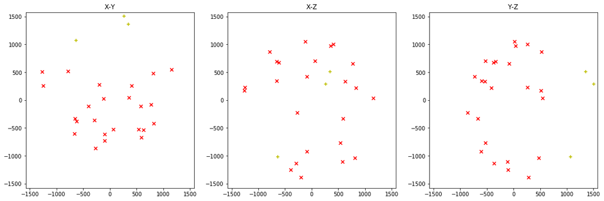

```
Distance to Jita: 39.8 AU
```

```python
p1 = [Decimal(x) for x in analyse_cluster(df, label=1)]

d = distance(p1, J44)
print(f"Distance to Jita: {format_dist(d)}")
```

```
ΔX range [-801, 728] m
ΔY range [-1003, 1129] m
ΔZ range [-1019, 1293] m
R range [568, 1719] m
Outliers: 1
```

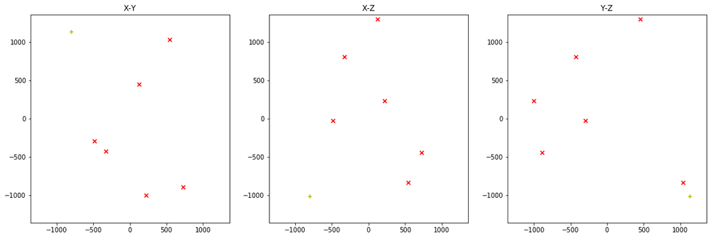

```
Distance to Jita: 39.7 AU
```

```python
p2 = [Decimal(x) for x in analyse_cluster(df, label=2)]

d = distance(p2, J44)
print(f"Distance to Jita: {format_dist(d)}")
```

The clusters are tight, but none of them appears to be anywhere near Jita 4-4. Missed opportunity? Perhaps the beasts only ever leave Jita assembled and otherwise arrive there in the belly or some freighter? Who knows...

## Getting There

Let's go visit the hunter's spot and say hi (or bump her, or protest somehow the killing of the magnificent bests.) Since we cannot simply warp to random 3d coordinates, we will be using bookmarks created in mid-warp.

The easiest thing to do is to board a Leopard in Jita 4-4 and set off for Perimeter, then hit the bookmark button once we are past the 6-th tick. A second later we will have the right bookmark, but also will most likely be dead and have lost 200M ISK in the process (unless we do it outside of her quite regular hunting schedule.) As there are no other ships that can do 20 AU/s, we cannot exactly reproduce the flight of the Leopard, but we can try using successive approximation. Let's write a function that shows what bookmarks we can set while warping as a function of warp distance and ship's max warp speed. We are charting the distance curve and sampling it every second along the time axis. Code is very similar to the function from the previous section, just this one uses time instead of distance and there are no comments :)

```python
def quantize_warp_dist(warp_dist, k, v_out=Decimal(100), target_radius=Decimal(), verbose=False):
    from decimal import ROUND_UP

    warp_dist -= target_radius

    k_acc = Decimal(k)
    k_dec = min(k_acc / Decimal(3), Decimal(2))

    if v_out is None:
        v_out = Decimal(k_dec)

    v_cruise = k_acc * AU

    d_acc = min(warp_dist / (Decimal(1) + k_acc / k_dec), AU)
    d_dec = d_acc * k_acc / k_dec
    d_out = v_out / k_dec
    d_cruise = warp_dist - d_acc - d_dec + d_out

    t_acc = d_acc.ln() / k_acc
    t_dec = d_dec.ln() / k_dec
    t_out = d_out.ln() / k_dec
    t_cruise = d_cruise / v_cruise

    t_total = t_acc + t_cruise + t_dec - t_out

    if verbose:
        print(f"Acceleration: {format_dist(d_acc)} in {format_time(t_acc)}")
        print("+")
        print(f"Cruise:       {format_dist(d_cruise)} in {format_time(t_cruise)}")
        print("+")
        print(f"Deceleration: {format_dist(d_dec)} in {format_time(t_dec)}")
        print("=")
        print(f"Total:        {format_dist(warp_dist)} in {format_time(t_total)}")

    t = 0
    bookmarks = []

    while t <= t_total.quantize(Decimal('1.'), rounding=ROUND_UP):
        if t <= t_acc:
            d = (k_acc * Decimal(t)).exp()
            phase = 'acceleration'
        elif t <= (t_acc + t_cruise):
            d = d_acc + (t - t_acc) * v_cruise
            phase = 'cruise'
        elif t <= t_total:
            d_in_dec = d_dec - (k_dec * (t_total + t_out - t)).exp()
            d = d_acc + d_cruise + d_in_dec
            phase = 'deceleration'
        else:
            d = warp_dist
            phase = 'out of warp'
        bookmarks.append({
            'Tick': t,
            'Distance from origin': format_dist(d),
            'Distance to target': format_dist(warp_dist - d + target_radius),
            'Warp phase': phase,
            'Travel distance in m': d.quantize(Decimal('1.')),
            'Distance left in m': (warp_dist - d).quantize(Decimal('1.'))
        })
        if verbose:
            print(f"Tick {t:2d}: {format_dist(d):>15s} from start, {format_dist(warp_dist - d):>15s} till end")
        t = t + 1

    return pd.DataFrame(bookmarks).set_index('Tick')
```

Let's say we have an Astero with a hyperspatial rig that warps at 6 AU/s. What options does that give us?

```python
d_gs = distance(J44, PG)
quantize_warp_dist(d_gs, 6.0, verbose=False)[['Distance from origin', 'Distance to target', 'Warp phase']]
```

| Tick | Distance from origin | Distance to target | Warp phase |
| --- | --- | --- | --- |
| 0 | 1 m | 39.8 AU | acceleration |
| 1 | 403 m | 39.8 AU | acceleration |
| 2 | 163 km | 39.8 AU | acceleration |
| 3 | 65660 km | 39.8 AU | acceleration |
| 4 | 0.2 AU | 39.6 AU | acceleration |
| 5 | 5.3 AU | 34.5 AU | cruise |
| 6 | 11.3 AU | 28.5 AU | cruise |
| 7 | 17.3 AU | 22.5 AU | cruise |
| 8 | 23.3 AU | 16.5 AU | cruise |
| 9 | 29.3 AU | 10.5 AU | cruise |
| 10 | 35.3 AU | 4.5 AU | cruise |
| 11 | 39.1 AU | 0.7 AU | deceleration |
| 12 | 39.7 AU | 13726369 km | deceleration |
| 13 | 39.8 AU | 1857662 km | deceleration |
| 14 | 39.8 AU | 251407 km | deceleration |
| 15 | 39.8 AU | 34024 km | deceleration |
| 16 | 39.8 AU | 4605 km | deceleration |
| 17 | 39.8 AU | 623 km | deceleration |
| 18 | 39.8 AU | 84 km | deceleration |
| 19 | 39.8 AU | 11 km | deceleration |
| 20 | 39.8 AU | 1495 m | deceleration |
| 21 | 39.8 AU | 159 m | deceleration |
| 22 | 39.8 AU | 0 m | out of warp |

Those are all the bookmarks we can set while warping from Jita 4-4 to the Perimeter gate while in the said Astero. The table applies for the journey in the opposite direction too, we just need to keep in mind what is origin and what is target. None of those bookmarks is exactly 290654 km from the gate, but some are close. And we can repeat the warp-bookmark process multiple times, each time recomputing the table and picking the optimal distance to bookmark at. We just have to remember to always approach the previous bookmark to 0 m first before we hit the next warp due to the randomisation of the warp-out point.

With a bit of perseverance, we end up in a place that is close enough and then slow-boat to our final location. The distance to the Perimeter gate is our guiding signal.

[figure not shown]

(Full disclosure: I did this with pure brute force mid-warp bookmarking before it even occurred to me to compute the table above. It worked anyway.)

## "Are we there yet?"

We reach the place outside the hunter's active hours. Even if she was online, we couldn't know if she's there unless we were super lucky to approach and decloak her. How can we know that we are where we should be? Let's find out the 3d coordinates of our bookmark.

We head to ESI and look at the API categories. There is one called Bookmarks. We open it. We see the `/characters/{character_id}/bookmarks/` endpoint supposedly providing a list of bookmarks with their 3d coordinate. We are happy. We authorise, put in our character ID, hit Execute and...

`[]`

We are sad. It turns out, the bookmark endpoints have been [temporarily blacked out](https://developers.eveonline.com/blog/article/temporary-blackout-of-esi-bookmarks) since 2019-11-25. As with any other temporary thing the blackout continues to this day.

Fortunately, we already know a piece of data that includes precise 3d coordinates. So we log in a poor suicidal alt, put her in a corvette, warp her to the location of our bookmark and open fire at our main alt. CONCORD is prompt to respond. Our poor alt loses security status and we gain the 3d location of our bookmark. [Another job well done.](https://www.youtube.com/watch?v=G-C1dRZ_hps)

To obtain the killmail, we go to ESI, authorize granting the `esi-killmails.read_killmails.v1` scope, then hit the `/characters/{character_id}/killmails/recent/` endpoint with the character ID of our kamikaze. We take the most recent killmail (with the highest ID) and use its ID and hash to retrieve the full killmail. Doing so using their own killmail is left as an exercise to the reader. Here we only show the relevant (and slightly randomised because *checks notes* GDPR) data from our own killmail.

```python
# alt_km = cached_esi_call('https://esi.evetech.net/latest/killmails/{YOUR_KILLMAIL_ID}/{YOUR_KILLMAIL_HASH}/')
alt_km = {
    'victim': {
        'position': {
            'x': -4067483552179.9825,
            'y': -710543302106.2847,
            'z': -3956408163310.318
        }
    }
}

alt_p = to_dvec(alt_km['victim']['position'])
d = distance(alt_p, p0)
print("Distance to point-0:", format_dist(d))
```

```
Distance to point-0: 6337 m
```

Close enough and still outside the range of the smartbombs :) Time to do something stupid like drop an appropriately named container.

[figure not shown]

By the way, CONCORD is having a party here in the middle of nowhere. After all, it looks like we've hit the right spot.

## Mission Accomplished!

We successfully analysed the killmails and determined both the location of the agent and the reason for being there. In the process, we learned a great deal about the mechanics of EVE. And we basically used code against CODE. That's really funny.

And not a single combat scanner probe was launched in the process. We don't want to scare anyone, do we?

## Post-Film Scene

We save the ESI cache by pickling it. Doing science is an iterative process :)

```python
import pickle

with open('esi.cache', 'wb') as f:
    pickle.dump(ESI_CACHE, f)

with open('zkill.cache', 'wb') as f:
    pickle.dump(ZKILL_CACHE, f)
```

## P.S.

After some hanging around her in space with our combat probes out in a stand-by location, we get lucky and our hunter decloaks (or rather gets decloaked) and stays like that long enough for us to scan her down. We get a perfect lock on her position. How far away it is from the cluster centroid?

```python
true_pos = to_dvec({'x':-4067483557855.123, 'y':-710543303075.456, 'z':-3956408162371.789})
print("Delta to probed position:", format_dist(distance(true_pos, p0)))
```

```
Delta to probed position: 614 m
```

She is a bit off. But the smartbomb range is 5 km, so it isn't a problem.

## P.<sup>2</sup>S.

Remember those other two small clusters? 64374 km and 0.1 AU from Perimeter gate respectively. Random locations?

```
Cluster 1
ΔX range [-1267, 1158] m
ΔY range [-860, 1502] m
ΔZ range [-1389, 1047] m
R range [851, 1611] m
Outliers: 3
```

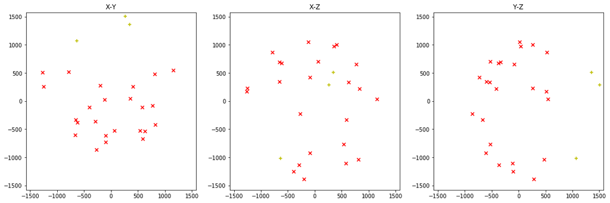

[output not shown]

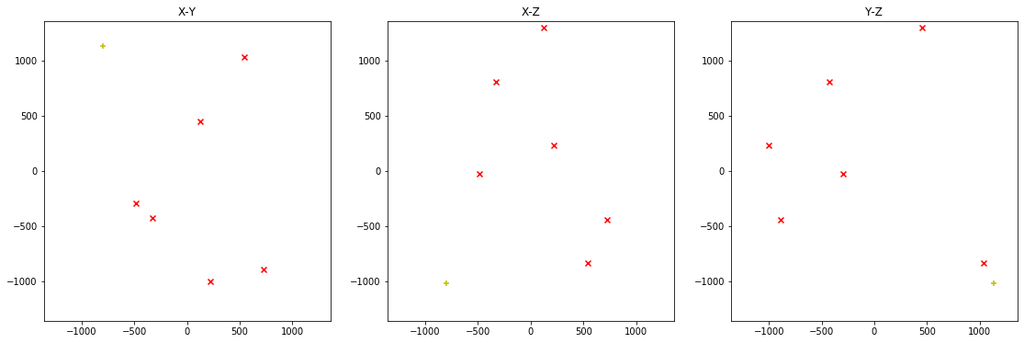

```
Best route:
(50001249) Stargate (Perimeter) <-> (60003760) Jita IV - Moon 4 - Caldari Navy Assembly Plant
  cos(ɸ) = 0.9999999999999995788446295872
  distance to warp line: 461 m
  distance to stargate: 0.1 AU
  distance to station: 39.7 AU
  t stargate to point: 0.838844 s
  t station to point: 4.754299 s
```

```python
for label in [1, 2]:
    print("Cluster", label)
    p = [Decimal(x) for x in analyse_cluster(df, label=label)]
    route = find_best_route(p)
    if route is not None:
        org = jita_space[route['origin']]
        o_pos = to_dvec(org['pos'])
        o_class = org['class']
        tgt = jita_space[route['target']]
        t_pos = to_dvec(tgt['pos'])
        t_class = tgt['class']
        cp = route['cosphi']
        print("Best route:")
        print(f"({route['origin']}) {org['name']}", '<->', f"({route['target']}) {tgt['name']}")
        print("  cos(ɸ) =", cp)
        d_op = distance(o_pos, p)
        d = d_op * (Decimal('1') - cp**2).sqrt()
        print(f"  distance to warp line:", format_dist(d))
        print(f"  distance to {o_class}:", format_dist(d_op))
        d = distance(t_pos, p)
        print(f"  distance to {t_class}:", format_dist(d))
        t, _ = warp_time_to_point(o_pos, t_pos, p, 28.0, target_radius=Decimal(tgt['radius']))
        print(f"  t {o_class} to point:", t.quantize(Decimal('.000001')), "s")
        t, _ = warp_time_to_point(t_pos, o_pos, p, 22.0, target_radius=Decimal(org['radius']))
        print(f"  t {t_class} to point:", t.quantize(Decimal('.000001')), "s")
```

Cluster 1 is still a bit of a mistery. It lines up with a warp route but its timing is out of sync with the server ticks in both directions. Further analysis is needed.

# P<sup>3</sup>.S.

After almost forgetting about it, the solution comes one day all of a sudden while doing something totally unrelated. It goes like this.

Let's look at timestamps of the killmails in Cluster 1:

```python
df['timestamp'] = pd.to_datetime(df['time'])
min_t = df[df.label == 1].timestamp.min() - pd.to_timedelta('1 days')
max_t = df[df.label == 1].timestamp.max() + pd.to_timedelta('1 days')
df[(df.timestamp >= min_t) & (df.timestamp <= max_t)]
```

| id | time | x | y | z | label | timestamp |
| --- | --- | --- | --- | --- | --- | --- |
| 95028274 | 2021-09-09T18:30:34Z | -4.067634e+12 | -7.105696e+11 | -3.956575e+12 | 1 | 2021-09-09 18:30:34+00:00 |
| 95010470 | 2021-09-08T16:23:20Z | -4.067634e+12 | -7.105696e+11 | -3.956575e+12 | 1 | 2021-09-08 16:23:20+00:00 |
| 95002811 | 2021-09-08T02:31:48Z | -4.067634e+12 | -7.105696e+11 | -3.956575e+12 | 1 | 2021-09-08 02:31:48+00:00 |
| 94997185 | 2021-09-07T19:23:23Z | -4.067634e+12 | -7.105696e+11 | -3.956575e+12 | 1 | 2021-09-07 19:23:23+00:00 |
| 94995859 | 2021-09-07T18:08:25Z | -4.067634e+12 | -7.105696e+11 | -3.956575e+12 | 1 | 2021-09-07 18:08:25+00:00 |
| 94992660 | 2021-09-07T14:01:19Z | -4.067634e+12 | -7.105696e+11 | -3.956575e+12 | 1 | 2021-09-07 14:01:19+00:00 |
| 94990878 | 2021-09-07T11:41:58Z | -4.067634e+12 | -7.105696e+11 | -3.956575e+12 | 1 | 2021-09-07 11:41:58+00:00 |
| 94984695 | 2021-09-06T23:08:22Z | -4.067634e+12 | -7.105696e+11 | -3.956575e+12 | 1 | 2021-09-06 23:08:22+00:00 |
| 94983328 | 2021-09-06T21:29:47Z | -4.067634e+12 | -7.105696e+11 | -3.956575e+12 | 1 | 2021-09-06 21:29:47+00:00 |
| 94957297 | 2021-09-05T15:57:05Z | -4.067634e+12 | -7.105696e+11 | -3.956575e+12 | 1 | 2021-09-05 15:57:05+00:00 |
| 94940405 | 2021-09-04T19:38:38Z | -4.067634e+12 | -7.105696e+11 | -3.956575e+12 | 1 | 2021-09-04 19:38:38+00:00 |
| 94938445 | 2021-09-04T18:15:52Z | -4.067634e+12 | -7.105696e+11 | -3.956575e+12 | 1 | 2021-09-04 18:15:52+00:00 |
| 94936242 | 2021-09-04T16:10:54Z | -4.067634e+12 | -7.105696e+11 | -3.956575e+12 | 1 | 2021-09-04 16:10:54+00:00 |
| 94934657 | 2021-09-04T14:54:17Z | -4.067634e+12 | -7.105696e+11 | -3.956575e+12 | 1 | 2021-09-04 14:54:17+00:00 |
| 94933149 | 2021-09-04T13:36:04Z | -4.067634e+12 | -7.105696e+11 | -3.956575e+12 | 1 | 2021-09-04 13:36:04+00:00 |
| 94924758 | 2021-09-04T02:17:22Z | -4.067634e+12 | -7.105696e+11 | -3.956575e+12 | 1 | 2021-09-04 02:17:22+00:00 |
| 94923951 | 2021-09-04T01:24:05Z | -4.067634e+12 | -7.105696e+11 | -3.956575e+12 | 1 | 2021-09-04 01:24:05+00:00 |
| 94920070 | 2021-09-03T21:10:43Z | -4.067634e+12 | -7.105696e+11 | -3.956575e+12 | 1 | 2021-09-03 21:10:43+00:00 |
| 94918342 | 2021-09-03T19:44:40Z | -4.067634e+12 | -7.105696e+11 | -3.956575e+12 | 1 | 2021-09-03 19:44:40+00:00 |
| 94917812 | 2021-09-03T19:17:03Z | -4.067634e+12 | -7.105696e+11 | -3.956575e+12 | 1 | 2021-09-03 19:17:03+00:00 |
| 94916171 | 2021-09-03T17:56:30Z | -4.067634e+12 | -7.105696e+11 | -3.956575e+12 | 1 | 2021-09-03 17:56:30+00:00 |
| 94911650 | 2021-09-03T14:02:38Z | -4.067634e+12 | -7.105696e+11 | -3.956575e+12 | 1 | 2021-09-03 14:02:38+00:00 |
| 94902529 | 2021-09-02T22:09:43Z | -4.067634e+12 | -7.105696e+11 | -3.956575e+12 | 1 | 2021-09-02 22:09:43+00:00 |
| 94901443 | 2021-09-02T20:48:09Z | -4.067634e+12 | -7.105696e+11 | -3.956575e+12 | 1 | 2021-09-02 20:48:09+00:00 |
| 94895461 | 2021-09-02T14:45:10Z | -4.067634e+12 | -7.105696e+11 | -3.956575e+12 | 1 | 2021-09-02 14:45:10+00:00 |
| 94886900 | 2021-09-01T23:39:02Z | -4.067634e+12 | -7.105696e+11 | -3.956575e+12 | 1 | 2021-09-01 23:39:02+00:00 |
| 94885979 | 2021-09-01T22:25:41Z | -4.067634e+12 | -7.105696e+11 | -3.956575e+12 | 1 | 2021-09-01 22:25:41+00:00 |

Looks like they all happen within the 9 days spanning from 2021-09-01 to 2021-09-09 with no killmals from the other spots inbetween. What is so special about that time period? The answer is *Caldari Union Day 2021* which began after downtime on 2021-09-01, granting 2 AU/s base warp speed bonus to all ships in Caldari space. This stacks up with the 300% bonus of the Leopard for an effective warp speed of 28 AU/s. If we plug 28 AU/s into the warp computation and look at the location at the seventh tick:

```python
quantize_warp_dist(distance(J44, PG), 28, target_radius=Decimal(PG_r)).loc[7, ['Distance to target', 'Warp phase']]
```

```
Distance to target        64373 km
Warp phase            deceleration
Name: 7, dtype: object
```

Et voilà!